# Chicago PD Districts and Beats Census Spatial Join

This notebook joins Chicago Police Department (CPD) district shapes with census tract shapes and statistics. The data covers 2001-2019. We use 2010 Census data for “All Years”.

**Police district boundaries**

The Chicago PD closed three districts (13th, 21st, and 23rd) in 2012 as part of a cost-cutting plan to close a $636 million budget gap ([Chicago Tribune, March 3, 2012](https://www.chicagotribune.com/news/breaking/chi-chicago-police-districts-close-in-costcutting-plan-20120303-story.html)). However, the online data’s police district field uses the present-day district, so we’ll only do a spacial join using the current shape files. (The published portions of our analysis that use district-level demographics start in 2013.)

- Current as of Dec. 19, 2012, from city’s [online data portal](https://data.cityofchicago.org/Public-Safety/Boundaries-Police-Districts-current-/fthy-xz3r)
- Depreciated December 18, 2012, from city’s [online data portal](https://data.cityofchicago.org/Public-Safety/Boundaries-Police-Districts-deprecated-on-12-18-20/p3h8-xsd4). ([pdf map](https://news.wttw.com/sites/default/files/Map%20of%20Chicago%20Police%20Districts%20and%20Beats.pdf))

**Police beats**

- Current as of Dec. 19, 2012, from city’s [online data portal](https://data.cityofchicago.org/Public-Safety/Boundaries-Police-Beats-current-/aerh-rz74).

**Census Tracts**

- 2010 Census Tracts, from city’s [online data portal](https://data.cityofchicago.org/Facilities-Geographic-Boundaries/Boundaries-Census-Tracts-2010/5jrd-6zik).
- 2000 Census Tracts, from city’s [online data portal](https://data.cityofchicago.org/Facilities-Geographic-Boundaries/Boundaries-Census-Tracts-2000/pt6c-hxpp).

**Census Bureau Stats**

- 2000 Census: Total population, race/ethnicity, poverty
- 2010 Census: Total population, race/ethnicity
- ACS 2010: Poverty, population earning $100K+
- ACS 2015: Poverty

**Note on “Hispanic or Latino” descent**

We used U.S. Census data on people who identify as “Hispanic or Latino” to calculate the racial and ethnic demographics of each district. The Trace uses “Latino” because fewer than 1 percent of those identifying as “Hispanic or Latino” in Cook County are of Spanish origin; most descend from Latin America and the Caribbean.

**Reference**

- Chicago Cop’s [webpage](https://www.chicagocop.com/archives/documents-archive/cartographs/) has current and historic pdfs of Chicago Police jurisdictions.
- Chicago Police [Oct 2011 presentation](http://ward32.org/wp-content/uploads/2011/10/Mayor-CPD-Briefing-Consolidation-101211.pdf) on consolidation plan.
- Chicago PD [landing page](https://home.chicagopolice.org/community/districts/) for police districts.
- City of Chicago [webpage](https://www.chicago.gov/city/en/depts/doit/supp_info/citywide_maps.html) on ward, community area and neighborhood maps.
- Census tract profiles on [censusreporter.org](https://censusreporter.org/profiles/14000US17031980000-census-tract-9800-cook-il/).

```r
rm(list=ls())
gc()
```

```
##          used (Mb) gc trigger (Mb) limit (Mb) max used (Mb)
## Ncells 459502 24.6     997604 53.3         NA   630517 33.7
## Vcells 901354  6.9    8388608 64.0     102400  1767894 13.5
```

```r
# Load default packages, report functions, disable scientific notation
source("./Functions/default.R")

# Math on st_intersection
st_intersection_f <- function(table1, table2) {
  st_intersection(table1, table2) %>%
    mutate(`fragment area` = st_area(geometry)) %>%
    # mutate(`fragment area` = round((as.numeric(`fragment area`)), 0)) %>%
    # filter(`fragment area` >= 100) %>%
    mutate(
      # area = round((as.numeric(area)), 0),
           # area.1 = round((as.numeric(area.1)), 0),
           `fragment percent` = `fragment area`/area) %>%
    replace(., is.na(.), 0) %>%
    st_set_geometry(NULL)
}
```

# 1 Load Data

## 1.1 Police District Shapes

```r
dist_current <- st_read("Input/CPD_district_shapes_current/geo_export_5a4ab56b-3798-4ed1-bd28-7774c5237614.shp") %>%
  st_transform(crs = 4326) %>%
  mutate(dist_num = str_pad(dist_num, 3, pad = "0")) %>%
  mutate(area = st_area(geometry))
```

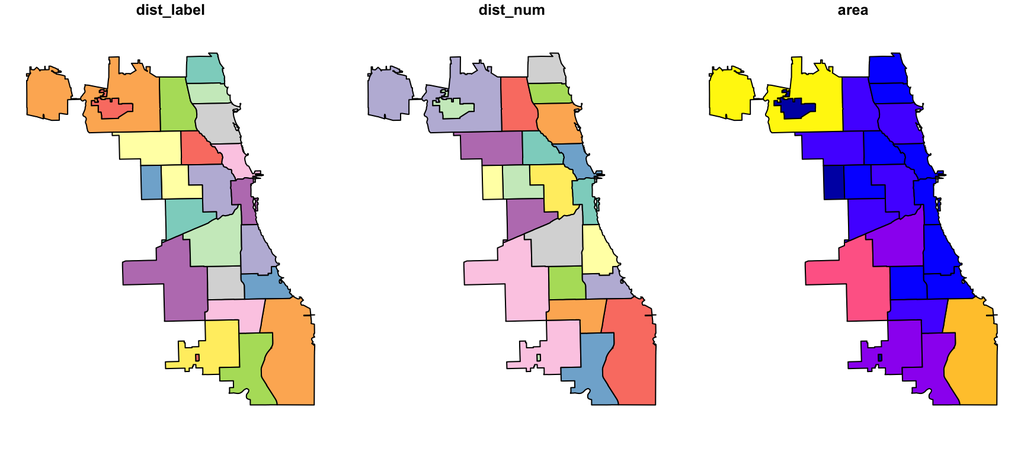

```r
plot(dist_current)
```

## 1.2 Police Beat Shapes

```r
beats_current <- st_read("Input/Police_Beats_Current/geo_export_5d875d6d-1fd7-4754-8847-fcf5d0f5bc77.shp") %>%
  st_transform(crs = 4326) %>%
  select(beat_curr = beat_num,
         district_curr = district,
         geometry) %>%
  mutate(beat_curr = as.character(beat_curr),
         area = st_area(geometry))
```

## 1.3 2000 Census Shapes and Stats

```r
tracts_2000 <- st_read("Input/Census_tracts_2000/geo_export_337cc9e4-2258-4a67-bd91-dd915899a317.shp") %>%
  st_transform(crs = 4326) %>%
  mutate(census_t_1 = as.character(census_t_1),
         tract_yr = "2000") %>%
  select(tract = census_t_1,
         geometry,
         tract_yr)
census_2000_names <- names(read_csv("Input/Census_Stats/DEC_00_SF3_P007/DEC_00_SF3_P007_with_ann.csv", n_max = 0))

census_2000 <- read_csv("Input/Census_Stats/DEC_00_SF3_P007/DEC_00_SF3_P007_with_ann.csv",
                        col_names = census_2000_names, skip = 2) %>%

       mutate(tract_blk_hisp = VD04 + VD10,
              tract_asian_pi = VD06 + VD07,
              tract_other = VD01 - (tract_blk_hisp + VD03 + tract_asian_pi),
              tract = as.character(GEO.id2) %>% str_replace("1714000", "17")) %>%
       select(tract,
              tract_total = VD01,
              tract_blk_hisp,
              tract_asian_pi,
              tract_other,
              tract_white = VD03,
              tract_blk = VD04,
              tract_hisp = VD10)

tracts_2000 <- tracts_2000 %>%
  left_join(census_2000, by = "tract") %>%

  # total poverty from 2000 census
  left_join(
    (read_csv("Input/Census_Stats/DEC_00_SF3_P087/DEC_00_SF3_P087_with_ann.csv") %>%
       clean_names() %>%
       select(tract = id2,
              tract_total_poverty = income_in_1999_below_poverty_level) %>%
       mutate(tract = as.character(tract)))
    , by = "tract") %>%

  mutate(area = st_area(geometry))
```

```r
make_report(as.data.table(tracts_2000))
```

| Column | # Distinct | # Not Missing | # Missing | % Missing | % Distinct |
| --- | --- | --- | --- | --- | --- |
| tract | 878 | 878 | 0 | 0 | 1 |
| area | 878 | 878 | 0 | 0 | 1 |
| geometry | 878 | 878 | 0 | 0 | 1 |
| # Records | 878 | 878 | 0 | 0 | 1 |
| tract_yr | 1 | 878 | 0 | 0 | 0.00113895216400911 |
| tract_total_poverty | 663 | 876 | 2 | 0.00227790432801822 | 0.755125284738041 |
| tract_total | 803 | 873 | 5 | 0.00569476082004556 | 0.914578587699317 |
| tract_blk_hisp | 777 | 873 | 5 | 0.00569476082004556 | 0.88496583143508 |
| tract_blk | 597 | 873 | 5 | 0.00569476082004556 | 0.67995444191344 |
| tract_white | 561 | 873 | 5 | 0.00569476082004556 | 0.638952164009112 |

[output cut: 3 more lines]

## 1.4 2010 Census Shapes and Stats

```r
tract_data_2010 <- st_read("Input/Census_tracts_2010/geo_export_603ae8ba-0139-4272-b6de-278a1230c4d3.shp") %>% st_transform(crs = 4326) %>%
  # GEOGCS["WGS84(DD)", DATUM["WGS84", SPHEROID["WGS84", 6378137.0, 298.257223563]], PRIMEM["Greenwich", 0.0], UNIT["degree", 0.017453292519943295], AXIS["Geodetic longitude", EAST], AXIS["Geodetic latitude", NORTH]]
  mutate(geoid10 = as.character(geoid10),
         tract_yr = "2010") %>%
  select(tract = geoid10,
         tract_yr,
         geometry)
census_2010_names <- names(read_csv("Input/Census_Stats/DEC_10_SF1_P5/DEC_10_SF1_P5_with_ann.csv", n_max = 0))

census_2010 <- read_csv("Input/Census_Stats/DEC_10_SF1_P5/DEC_10_SF1_P5_with_ann.csv",
                        col_names = census_2010_names, skip = 2) %>%

       # population, race/ethnicity from 2010 census
       mutate(tract_blk_hisp = as.numeric(D010 + D004),
              tract_asian_pi = as.numeric(D006 + D007),
              tract_other = (as.numeric(D001)) - (tract_blk_hisp + (as.numeric(D003)) + tract_asian_pi),
              tract = as.character(GEO.id2),
              tract_total = as.numeric(D001),
              tract_white = as.numeric(D003),
              tract_blk = as.numeric(D004),
              tract_hisp = as.numeric(D010),
              tract = as.character(GEO.id2) %>% str_replace("1714000", "17")) %>%
       select(tract,
              tract_total,
              tract_blk_hisp,
              tract_asian_pi,
              tract_other,
              tract_white,
              tract_blk,
              tract_hisp)

tracts_2010 <- tract_data_2010 %>%
  left_join(census_2010, by = "tract") %>%
  # total poverty 2010 ACS
  left_join(
    (read_csv("Input/Census_Stats/ACS_10_5YR_B17001/ACS_10_5YR_B17001_with_ann.csv") %>%
       clean_names() %>%
       select(tract = id2,
              tract_total_poverty = estimate_income_in_the_past_12_months_below_poverty_level) %>%
       mutate(tract = as.character(tract))),
    by = "tract") %>%

  # share of tract that earns income $100K + from 2010 ACS
  left_join(
    (read_csv("Input/Census_Stats/ACS_10_5YR_S1901/ACS_10_5YR_S1901_with_ann.csv") %>%
       # this is actually a percentage
       mutate(tract_100Kplus = (as.numeric(HC01_EST_VC09) +
                                  as.numeric(HC01_EST_VC10) +
                                  as.numeric(HC01_EST_VC11)
                                )/100,
              tract = as.character(GEO.id2)) %>%
       select(tract, tract_100Kplus)),
    by = "tract") %>%

  mutate(tract_100Kplus = tract_total * tract_100Kplus) %>%

  mutate(area = st_area(geometry))
```

```r
acs_2017_names <- names(read_csv("Input/Census_Stats/ACS_17_5YR_B03002/ACS_17_5YR_B03002_with_ann.csv", n_max = 0))

acs_2017 <- read_csv("Input/Census_Stats/ACS_17_5YR_B03002/ACS_17_5YR_B03002_with_ann.csv",
                        col_names = acs_2017_names, skip = 2) %>%

       # population, race/ethnicity from 2010 census
       mutate(tract_blk_hisp = as.numeric(HD01_VD12 + HD01_VD04),
              tract_asian_pi = as.numeric(HD01_VD06 + HD01_VD07),
              tract_other = (as.numeric(HD01_VD01)) - (tract_blk_hisp + (as.numeric(HD01_VD03)) + tract_asian_pi),
              tract = as.character(GEO.id2),
              tract_total = as.numeric(HD01_VD01),
              tract_white = as.numeric(HD01_VD03),
              tract_blk = as.numeric(HD01_VD04),
              tract_hisp = as.numeric(HD01_VD12),
              tract = as.character(GEO.id2) %>% str_replace("1714000", "17")) %>%
       select(tract,
              tract_total,
              tract_blk_hisp,
              tract_asian_pi,
              tract_other,
              tract_white,
              tract_blk,
              tract_hisp)

tracts_2017 <- tract_data_2010 %>%
  left_join(acs_2017, by = "tract") %>%
  mutate(area = st_area(geometry), tract_yr = "2017")
```

# 2 District and Census Spatial Join

Using [st_intersection](https://r-spatial.github.io/sf/reference/st_join.html): If a geometry or geography shares any portion of space then they intersect. ST_Intersects pulls in all Overlaps, Touches, Within all imply spatial intersection. If any of the aforementioned returns true, then the geometries also spatially intersect. Disjoint implies false for spatial intersection. I’m using this because the population within an RD is fluid.

```r
citywide <- bind_rows(
  st_set_geometry(tracts_2000, NULL),
  st_set_geometry(tracts_2010, NULL),
  st_set_geometry(tracts_2017, NULL)) %>%
  mutate(dist_label = "Citywide",
         dist_num = "099",
         `fragment percent` = 1) %>%
  select(-c(area))

dist_tracts_current <- bind_rows(
    (st_intersection_f(tracts_2000, dist_current)),
    (st_intersection_f(tracts_2010, dist_current)),
    (st_intersection_f(tracts_2017, dist_current))) %>%
  select(-c(area.1, `fragment area`, area)) %>%
  group_by(tract_yr, tract) %>%
  mutate(total_pct = sum(`fragment percent`)) %>%
  mutate(`fragment percent` = `fragment percent` * 1 / total_pct)


dist_tracts_current <- bind_rows(citywide, dist_tracts_current) %>%
  replace(., is.na(.), 0) %>%
  # calculate the total in the tract by the percent of the tract within the police district
  mutate(dist_total = as.numeric(tract_total * `fragment percent`),
         dist_blk_hisp = as.numeric(tract_blk_hisp * `fragment percent`),
         dist_asian_pi = as.numeric(tract_asian_pi * `fragment percent`),
         dist_other = as.numeric(tract_other * `fragment percent`),
         dist_white = as.numeric(tract_white * `fragment percent`),
         dist_blk = as.numeric(tract_blk * `fragment percent`),
         dist_hisp = as.numeric(tract_hisp * `fragment percent`),
         dist_100Kplus = as.numeric(tract_100Kplus * `fragment percent`)
         ) %>%
  rename(location_police_district_name = dist_label,
         location_police_district = dist_num,
         cen_yr = tract_yr) %>%
  # select(-c(`fragment percent`)) %>%
  # drop all columns containing tract name instead of dist name
  select(-contains("tract_"))
```

## 2.1 District Summary

- Sum all tracts within district
- Create a “Citywide” summary
- Calculate each year in between census using the average change per year
- Calculate percentages

```r
leftovers <- dist_tracts_current %>%
  filter(is.na(location_police_district_name))

dist_tracts_sum_current <- dist_tracts_current %>%
       # sum all the census tract values per district
       group_by(location_police_district_name,
                location_police_district,
                cen_yr) %>%
       summarise_if(is.numeric, (funs(sum))) %>%
  select(-c(`fragment percent`, total_pct))

dist_tracts_sum_current <- dist_tracts_sum_current %>%
  # take out excess rows when 2015 is all NA values
  filter(dist_total>1) %>%
  select(location_police_district_name,
         location_police_district,
         cen_yr, everything()) %>%
  gather("measure", "value", dist_total:dist_100Kplus) %>%
  spread(cen_yr, value) %>%

  # calculate an even amount of change between the censuses to calculate the years in between
  mutate(change_00_10 = (`2010` - `2000`)/ 10,
         change_10_17 = (`2017` - `2010`)/ 7) %>%

  mutate(`2000` = ifelse(measure == "dist_100Kplus", `2010`,
                         `2000`),
         `2001` = ifelse(measure == "dist_100Kplus", `2010`,
                         `2000`+ change_00_10),
         `2002` = ifelse(measure == "dist_100Kplus", `2010`,
                         `2001`+ change_00_10),
         `2003` = ifelse(measure == "dist_100Kplus", `2010`,
                         `2002`+ change_00_10),
         `2004` = ifelse(measure == "dist_100Kplus", `2010`,
                         `2003`+ change_00_10),
         `2005` = ifelse(measure == "dist_100Kplus", `2010`,
                         `2004`+ change_00_10),
         `2006` = ifelse(measure == "dist_100Kplus", `2010`,
                         `2005`+ change_00_10),
         `2007` = ifelse(measure == "dist_100Kplus", `2010`,
                         `2006`+ change_00_10),
         `2008` = ifelse(measure == "dist_100Kplus", `2010`,
                         `2007`+ change_00_10),
         `2009` = ifelse(measure == "dist_100Kplus", `2010`,
                         `2008`+ change_00_10),

         `2011` = ifelse(measure == "dist_100Kplus", `2010`,
                         `2010`+ change_10_17),
         `2012` = ifelse(measure == "dist_100Kplus", `2010`,
                         `2011`+ change_10_17),
         `2013` = ifelse(measure == "dist_100Kplus", `2010`,
                         `2012`+ change_10_17),
         `2014` = ifelse(measure == "dist_100Kplus", `2010`,
                         `2013`+ change_10_17),
         `2015` = ifelse(measure == "dist_100Kplus", `2010`,
                         `2014`+ change_10_17),
         `2016` = ifelse(measure == "dist_100Kplus", `2010`,
                         `2015`+ change_10_17),
         `2018` = ifelse(measure == "dist_100Kplus", `2010`,
                         `2017`+ change_10_17),
         `2019` = ifelse(measure == "dist_100Kplus", `2010`,
                         `2018`+ change_10_17)
  ) %>%


  select(-c(change_00_10, change_10_17)) %>%
  gather("year", "value", `2000`:`2019`) %>%
  spread(measure, value) %>%

  # calcculate percents
  mutate(dist_percent_blk_hisp = round((dist_blk_hisp/dist_total), digits = 2),
         dist_percent_white = round((dist_white/dist_total), digits = 2),
         dist_percent_blk = round((dist_blk/dist_total), digits = 2),
         dist_percent_hisp = round((dist_hisp/dist_total), digits = 2),
         dist_percent_non_white = 1 - dist_percent_white,
         dist_percent_100Kplus = round((dist_100Kplus/
                                           dist_total[which(year == "2010")]), digits = 2))

# Make an "all years" row using 2010 numbers
dist_tracts_sum_current <-
  bind_rows(
    dist_tracts_sum_current,
    (
      dist_tracts_sum_current %>%
        filter(year == "2010") %>%
        mutate(year = "All Years")
    )
  )
```

## 2.2 Combined fields

```r
dist_tracts_sum_current <- dist_tracts_sum_current %>%
  #removing 31st police district because it's not a real district and isn't used in our analysis
  filter(location_police_district != "031") %>%

  mutate(dist_bucket_per_blk_hisp = case_when(dist_percent_blk_hisp >= .8 ~ "80-100",
                                              dist_percent_blk_hisp >= .6 ~ "60-80",
                                              dist_percent_blk_hisp >= .4 ~ "40-60",
                                              dist_percent_blk_hisp >= .2 ~ "20-40",
                                              dist_percent_blk_hisp >= 0 ~ "0-20",
                                              TRUE ~ as.character(NA)),
         dist_bucket_per_blk_hisp = factor(dist_bucket_per_blk_hisp,
                                           levels=c("0-20", "20-40", "40-60",
                                                    "60-80", "80-100"),
                                           labels=c("0-20", "20-40", "40-60",
                                                    "60-80", "80-100")),
         dist_bucket_per_white = case_when(dist_percent_white >= .8 ~ "80-100",
                                           dist_percent_white >= .6 ~ "60-80",
                                           dist_percent_white >= .4 ~ "40-60",
                                           dist_percent_white >= .2 ~ "20-40",
                                           dist_percent_white >= 0 ~ "0-20",
                                           TRUE ~ as.character(NA)),
         dist_bucket_per_white = factor(dist_bucket_per_white,
                                        levels=c("0-20", "20-40", "40-60",
                                                 "60-80", "80-100"),
                                        labels=c("0-20", "20-40", "40-60",
                                                 "60-80", "80-100")),
         # add present-day police area
         location_area = recode(location_police_district,
                                `011` = "North",
                                `014` = "North",
                                `015` = "North",
                                `016` = "North",
                                `017` = "North",
                                `019` = "North",
                                `020` = "North",
                                `024` = "North",
                                `025` = "North",
                                `001` = "Central",
                                `002` = "Central",
                                `003` = "Central",
                                `008` = "Central",
                                `009` = "Central",
                                `010` = "Central",
                                `012` = "Central",
                                `018` = "Central",
                                `004` = "South",
                                `005` = "South",
                                `006` = "South",
                                `007` = "South",
                                `022` = "South",
                                `099` = "Citywide"))
```

## 2.3 Check data

```r
dist_tracts_sum_current %>% group_by(dist_bucket_per_blk_hisp) %>% summarise(n=n())
```

```
## # A tibble: 5 x 2
##   dist_bucket_per_blk_hisp     n
##   <fct>                    <int>
## 1 0-20                        43
## 2 20-40                       79
## 3 40-60                       60
## 4 60-80                      114
## 5 80-100                     187
```

```r
dist_tracts_sum_current %>% group_by(location_area) %>% summarise(n=n())
```

```
## # A tibble: 4 x 2
##   location_area     n
##   <chr>         <int>
## 1 Central         168
## 2 Citywide         21
## 3 North           189
## 4 South           105
```

```r
# make sure each district has a population for all years:
dist_tracts_sum_current %>%
  group_by(location_police_district, year) %>%
  summarise(n = round((sum(dist_total)), 0)) %>%
  spread(year, n)
```

```
## # A tibble: 23 x 22
## # Groups:   location_police_district [23]
##    location_police… `2000` `2001` `2002` `2003` `2004` `2005` `2006` `2007`
##    <chr>             <dbl>  <dbl>  <dbl>  <dbl>  <dbl>  <dbl>  <dbl>  <dbl>
##  1 001               37653  40413  43174  45935  48695  51456  54217  56977
##  2 002              112983 111104 109225 107345 105466 103587 101708  99828
##  3 003               89256  87969  86681  85394  84107  82820  81533  80246
##  4 004              144728 142832 140936 139040 137144 135248 133353 131457
##  5 005               92823  91004  89185  87367  85548  83729  81910  80091
##  6 006              105905 104459 103013 101567 100121  98674  97228  95782
##  7 007               90191  88194  86198  84202  82205  80209  78212  76216
##  8 008              242719 243212 243705 244199 244692 245186 245679 246173
##  9 009              178032 176945 175858 174771 173685 172598 171511 170424
## 10 010              132302 130514 128726 126939 125151 123364 121576 119788
## # … with 13 more rows, and 13 more variables: `2008` <dbl>, `2009` <dbl>,
## #   `2010` <dbl>, `2011` <dbl>, `2012` <dbl>, `2013` <dbl>, `2014` <dbl>,
## #   `2015` <dbl>, `2016` <dbl>, `2017` <dbl>, `2018` <dbl>, `2019` <dbl>,
## #   `All Years` <dbl>
```

**Checking the population sum of the districts with Chicago’s total population**

Citywide population, according to Census:

```r
dist_tracts_sum_current %>%
  filter(location_police_district_name != "Citywide") %>%
  group_by(year) %>%
  summarize(total = sum(dist_total))
```

```
## # A tibble: 21 x 2
##    year     total
##    <chr>    <dbl>
##  1 2000  2895802.
##  2 2001  2875740.
##  3 2002  2855678.
##  4 2003  2835616.
##  5 2004  2815554.
##  6 2005  2795492.
##  7 2006  2775429.
##  8 2007  2755367.
##  9 2008  2735305.
## 10 2009  2715243.
## # … with 11 more rows
```

```r
make_report(as.data.table(dist_tracts_sum_current))
```

| Column | # Distinct | # Not Missing | # Missing | % Missing | % Distinct |
| --- | --- | --- | --- | --- | --- |
| # Records | 483 | 483 | 0 | 0 | 1 |
| dist_asian_pi | 460 | 483 | 0 | 0 | 0.952380952380952 |
| dist_blk | 460 | 483 | 0 | 0 | 0.952380952380952 |
| dist_blk_hisp | 460 | 483 | 0 | 0 | 0.952380952380952 |
| dist_hisp | 460 | 483 | 0 | 0 | 0.952380952380952 |
| dist_other | 460 | 483 | 0 | 0 | 0.952380952380952 |
| dist_total | 460 | 483 | 0 | 0 | 0.952380952380952 |
| dist_white | 460 | 483 | 0 | 0 | 0.952380952380952 |
| dist_percent_blk_hisp | 80 | 483 | 0 | 0 | 0.165631469979296 |
| dist_percent_blk | 73 | 483 | 0 | 0 | 0.151138716356108 |

[output cut: 11 more lines]

## 2.4 Write districts csv

```r
dist_tracts_sum_current %>% write_csv("Output/police_districts_tracts_sum.csv")
```

# 3 Beats and Census Join

```r
citywide <- bind_rows(
  st_set_geometry(tracts_2010, NULL),
  st_set_geometry(tracts_2017, NULL)) %>%
  mutate(beat_curr = "099",
         district_curr = "099",
         `fragment percent` = 1) %>%
  select(-c(area))

beats_tracts_current <- bind_rows(
    (st_intersection_f(tracts_2010, beats_current)),
    (st_intersection_f(tracts_2017, beats_current))) %>%
  select(-c(area.1, `fragment area`, area)) %>%
  group_by(tract_yr, tract) %>%
  mutate(total_pct = sum(`fragment percent`)) %>%
  mutate(`fragment percent` = `fragment percent` * 1 / total_pct)


beats_tracts_current <- bind_rows(citywide, beats_tracts_current) %>%
  replace(., is.na(.), 0) %>%
  # calculate the total in the tract by the percent of the tract within the police beat
  mutate(beat_total = as.numeric(tract_total * `fragment percent`),
         beat_blk_hisp = as.numeric(tract_blk_hisp * `fragment percent`),
         beat_asian_pi = as.numeric(tract_asian_pi * `fragment percent`),
         beat_other = as.numeric(tract_other * `fragment percent`),
         beat_white = as.numeric(tract_white * `fragment percent`),
         beat_blk = as.numeric(tract_blk * `fragment percent`),
         beat_hisp = as.numeric(tract_hisp * `fragment percent`),
         beat_100Kplus = as.numeric(tract_100Kplus * `fragment percent`)
         ) %>%
  rename(location_police_beat = beat_curr,
         location_police_district = district_curr,
         cen_yr = tract_yr) %>%
  # select(-c(`fragment percent`)) %>%
  # drop all columns containing tract name instead of dist name
  select(-contains("tract_"))

make_report(as.data.table(beats_tracts_current))
```

| Column | # Distinct | # Not Missing | # Missing | % Missing | % Distinct |
| --- | --- | --- | --- | --- | --- |
| # Records | 6794 | 6794 | 0 | 0 | 1 |
| beat_total | 6483 | 6794 | 0 | 0 | 0.954224315572564 |
| beat_blk_hisp | 6425 | 6794 | 0 | 0 | 0.945687371209891 |
| beat_blk | 5998 | 6794 | 0 | 0 | 0.882837798057109 |
| beat_white | 5930 | 6794 | 0 | 0 | 0.872828966735355 |
| beat_hisp | 5927 | 6794 | 0 | 0 | 0.87238740064763 |
| beat_other | 4907 | 6794 | 0 | 0 | 0.722254930821313 |
| beat_asian_pi | 4570 | 6794 | 0 | 0 | 0.672652340300265 |
| beat_100Kplus | 3203 | 6794 | 0 | 0 | 0.471445392993818 |
| fragment percent | 2558 | 6794 | 0 | 0 | 0.376508684133059 |

[output cut: 5 more lines]

## 3.1 Beats summary

- Sum all beats within district
- Create a “Citywide” summary
- Calculate each year in between census using the average change per year
- Calculate percentages

```r
leftovers <- beats_tracts_current %>%
  filter(is.na(location_police_district))

beats_tracts_sum_current <- beats_tracts_current %>%
       # sum all the census tract values per district
       group_by(location_police_beat, location_police_district,
                cen_yr) %>%
       summarise_if(is.numeric, (funs(sum))) %>%
  select(-c(`fragment percent`, total_pct))

beats_tracts_sum_current <- beats_tracts_sum_current %>%
  # take out excess rows when 2015 is all NA values
  filter(beat_total>1) %>%
  select(location_police_beat, location_police_district,
         cen_yr, everything()) %>%
  gather("measure", "value", beat_total:beat_100Kplus) %>%
  spread(cen_yr, value) %>%

  # calculate an even amount of change between the censuses to calculate the years in between
  mutate(change_10_17 = (`2017` - `2010`)/ 7) %>%

  mutate(
         `2011` = ifelse(measure == "beat_100Kplus", `2010`,
                         `2010`+ change_10_17),
         `2012` = ifelse(measure == "beat_100Kplus", `2010`,
                         `2011`+ change_10_17),
         `2013` = ifelse(measure == "beat_100Kplus", `2010`,
                         `2012`+ change_10_17),
         `2014` = ifelse(measure == "beat_100Kplus", `2010`,
                         `2013`+ change_10_17),
         `2015` = ifelse(measure == "beat_100Kplus", `2010`,
                         `2014`+ change_10_17),
         `2016` = ifelse(measure == "beat_100Kplus", `2010`,
                         `2015`+ change_10_17),
         `2018` = ifelse(measure == "beat_100Kplus", `2010`,
                         `2017`+ change_10_17),
         `2019` = ifelse(measure == "beat_100Kplus", `2010`,
                         `2018`+ change_10_17)
  ) %>%


  select(-c(change_10_17)) %>%
  gather("year", "value", `2010`:`2019`) %>%
  spread(measure, value) %>%

  # calcculate percents
  mutate(beat_percent_blk_hisp = round((beat_blk_hisp/beat_total), digits = 2),
         beat_percent_white = round((beat_white/beat_total), digits = 2),
         beat_percent_blk = round((beat_blk/beat_total), digits = 2),
         beat_percent_hisp = round((beat_hisp/beat_total), digits = 2),
         beat_percent_non_white = 1 - beat_percent_white,
         beat_percent_100Kplus = round((beat_100Kplus/
                                           beat_total[which(year == "2010")]), digits = 2))

# Make an "all years" row using 2010 numbers
beats_tracts_sum_current <-
  bind_rows(
    beats_tracts_sum_current,
    (
      beats_tracts_sum_current %>%
        filter(year == "2010") %>%
        mutate(year = "All Years")
    )
  )
```

## 3.2 Combined fields

```r
beats_tracts_sum_current <- beats_tracts_sum_current %>%
  as.data.frame() %>%
  #removing 31st police district because it's not a real district and isn't used in our analysis
  filter(location_police_district != "031") %>%
  mutate(location_police_district = str_pad(location_police_district, 3, pad = "0"),
         beat_bucket_per_blk_hisp = case_when(beat_percent_blk_hisp >= .8 ~ "80-100",
                                              beat_percent_blk_hisp >= .6 ~ "60-80",
                                              beat_percent_blk_hisp >= .4 ~ "40-60",
                                              beat_percent_blk_hisp >= .2 ~ "20-40",
                                              beat_percent_blk_hisp >= 0.00 ~ "0-20",
                                              TRUE ~ as.character(NA)),
         beat_bucket_per_blk_hisp = factor(beat_bucket_per_blk_hisp,
                                           levels=c("0-20", "20-40", "40-60",
                                                    "60-80", "80-100"),
                                           labels=c("0-20", "20-40", "40-60",
                                                    "60-80", "80-100")),
         beat_bucket_per_white = case_when(beat_percent_white >= .8 ~ "80-100",
                                              beat_percent_white >= .6 ~ "60-80",
                                              beat_percent_white >= .4 ~ "40-60",
                                              beat_percent_white >= .2 ~ "20-40",
                                           beat_percent_white >= 0.00 ~ "0-20",
                                              TRUE ~ as.character(NA)),
         beat_bucket_per_white = factor(beat_bucket_per_white,
                                           levels=c("0-20", "20-40", "40-60",
                                                    "60-80", "80-100"),
                                           labels=c("0-20", "20-40", "40-60",
                                                    "60-80", "80-100")),
         # add present-day police area
         location_area = recode(location_police_district,
                                `011` = "North",
                                `014` = "North",
                                `015` = "North",
                                `016` = "North",
                                `017` = "North",
                                `019` = "North",
                                `020` = "North",
                                `024` = "North",
                                `025` = "North",
                                `001` = "Central",
                                `002` = "Central",
                                `003` = "Central",
                                `008` = "Central",
                                `009` = "Central",
                                `010` = "Central",
                                `012` = "Central",
                                `018` = "Central",
                                `004` = "South",
                                `005` = "South",
                                `006` = "South",
                                `007` = "South",
                                `022` = "South"))
```

## 3.3 Check data

```r
beats_tracts_sum_current %>% group_by(beat_bucket_per_blk_hisp) %>% summarise(n=n())
```

```
## # A tibble: 6 x 2
##   beat_bucket_per_blk_hisp     n
##   <fct>                    <int>
## 1 0-20                       407
## 2 20-40                      463
## 3 40-60                      282
## 4 60-80                      271
## 5 80-100                    1559
## 6 <NA>                        10
```

```r
beats_tracts_sum_current %>% group_by(location_area) %>% summarise(n=n())
```

```
## # A tibble: 5 x 2
##   location_area     n
##   <chr>         <int>
## 1 031              11
## 2 099              11
## 3 Central        1177
## 4 North          1166
## 5 South           627
```

```r
# make sure each district has a population for all years:
beats_tracts_sum_current %>%
  group_by(location_police_beat, year) %>%
  summarise(n = round((sum(beat_total)), 0)) %>%
  spread(year, n)
```

```
## # A tibble: 272 x 12
## # Groups:   location_police_beat [272]
##    location_police… `2010` `2011` `2012` `2013` `2014` `2015` `2016` `2017`
##    <chr>             <dbl>  <dbl>  <dbl>  <dbl>  <dbl>  <dbl>  <dbl>  <dbl>
##  1 0111               2346   2428   2510   2592   2674   2755   2837   2919
##  2 0112               1079   1130   1181   1233   1284   1335   1386   1438
##  3 0113                771    817    862    907    953    998   1043   1089
##  4 0114              13877  14221  14566  14910  15255  15600  15944  16289
##  5 0121               6036   6246   6456   6666   6877   7087   7297   7507
##  6 0122               2804   3024   3244   3464   3684   3904   4125   4345
##  7 0123               9189   9414   9638   9863  10088  10313  10538  10763
##  8 0124               2544   2666   2787   2909   3030   3152   3273   3395
##  9 0131               6643   6681   6719   6757   6795   6833   6871   6909
## 10 0132              14510  14787  15065  15342  15620  15897  16175  16452
## # … with 262 more rows, and 3 more variables: `2018` <dbl>, `2019` <dbl>,
## #   `All Years` <dbl>
```

**Checking the population sum of the districts with Chicago’s total population**

Citywide population, according to Census:

```r
beats_tracts_sum_current %>%
  filter(!is.na(beat_total) & location_police_district != "099") %>%
  group_by(year) %>%
  summarise(n = round((sum(beat_total)), 0))
```

[output not shown]

```r
make_report(as.data.table(beats_tracts_sum_current))
```

| Column | # Distinct | # Not Missing | # Missing | % Missing | % Distinct |
| --- | --- | --- | --- | --- | --- |
| # Records | 2992 | 2992 | 0 | 0 | 1 |
| location_police_beat | 272 | 2992 | 0 | 0 | 0.0909090909090909 |
| location_police_district | 24 | 2992 | 0 | 0 | 0.00802139037433155 |
| year | 11 | 2992 | 0 | 0 | 0.00367647058823529 |
| location_area | 5 | 2992 | 0 | 0 | 0.00167112299465241 |
| beat_blk | 2713 | 2982 | 10 | 0.00334224598930481 | 0.906751336898396 |
| beat_blk_hisp | 2713 | 2982 | 10 | 0.00334224598930481 | 0.906751336898396 |
| beat_hisp | 2713 | 2982 | 10 | 0.00334224598930481 | 0.906751336898396 |
| beat_other | 2713 | 2982 | 10 | 0.00334224598930481 | 0.906751336898396 |
| beat_total | 2713 | 2982 | 10 | 0.00334224598930481 | 0.906751336898396 |

[output cut: 11 more lines]

## 3.4 Write beats csv

```r
beats_tracts_sum_current %>% write_csv("Output/police_beats_tracts_sum.csv")
```